# HW4

Hakan Ekiz - IE48B - Fall2021

23 Ocak 2022

## Introduction

Our aim in this study is to predict production values hourly for day of d+1 in the day of d In the day of d we have values until the day of d-1. We have;

DSWRF_Surface

RH_2.m.above.ground

TCDC_entire.atmosphere

TCDC_high.cloud.layer

TCDC_low.cloud.layer

TCDC_middle.cloud.layer

TMP_2.m.above.ground

including 7 different variables of 25 different locations. In total, there are 175 different variable values.

TMP: Temperature

RH: Relative humidity

DSWRF: Downward shortwave radiation flux

TCDC: Total cloud cover data (in terms of percentage) (at entire atmosphere,high cloud layer,lowcloud layer,middle cloud layer)

```r
require(data.table)
require(ggplot2)
require(repr)
require(rpart)
require(rpart.plot)
require(rattle)
require(TSrepr)
require(TSdist)
require(dtw)
require(zoo)
require(genlasso)
require(e1071)
require(lubridate)
require(forecast)
require(dplyr)
require(MLmetrics)
```

```r
options(repr.plot.width=15, repr.plot.height=8)

current_folder=getwd()
```

## Data

```r
data=fread('production_with_weather_data.csv')
head(data)
```

```
##          date hour production DSWRF_surface_38_35 DSWRF_surface_38_35.25
## 1: 2019-09-01    0     0.0000                   0                      0
## 2: 2019-09-01    1     0.0000                   0                      0
## 3: 2019-09-01    2     0.0000                   0                      0
## 4: 2019-09-01    3     0.0000                   0                      0
## 5: 2019-09-01    4     0.0000                   0                      0
## 6: 2019-09-01    5     0.1912                   0                      0
##    DSWRF_surface_38_35.5 DSWRF_surface_38_35.75 DSWRF_surface_38_36
## 1:                     0                      0                   0
## 2:                     0                      0                   0
## 3:                     0                      0                   0
## 4:                     0                      0                   0
## 5:                     0                      0                   0
## 6:                     0                      0                   0
##    DSWRF_surface_38.25_35 DSWRF_surface_38.25_35.25 DSWRF_surface_38.25_35.5
```

[output cut: 573 more lines]

Data consist of date, hour, production values and other 175 variables which is explained above.

```r
train1=data
train1[,trnd:=1:.N]
train1[,mon:=as.character(month(date,label=T))]
train1[,w_day:=as.character(wday(date,label=T))]


head(train1)
```

```
##          date hour production DSWRF_surface_38_35 DSWRF_surface_38_35.25
## 1: 2019-09-01    0     0.0000                   0                      0
## 2: 2019-09-01    1     0.0000                   0                      0
## 3: 2019-09-01    2     0.0000                   0                      0
## 4: 2019-09-01    3     0.0000                   0                      0
## 5: 2019-09-01    4     0.0000                   0                      0
## 6: 2019-09-01    5     0.1912                   0                      0
##    DSWRF_surface_38_35.5 DSWRF_surface_38_35.75 DSWRF_surface_38_36
## 1:                     0                      0                   0
## 2:                     0                      0                   0
## 3:                     0                      0                   0
## 4:                     0                      0                   0
## 5:                     0                      0                   0
## 6:                     0                      0                   0
##    DSWRF_surface_38.25_35 DSWRF_surface_38.25_35.25 DSWRF_surface_38.25_35.5
```

[output cut: 573 more lines]

In order to set a model we create new columns which are weekday information, month information and trend.

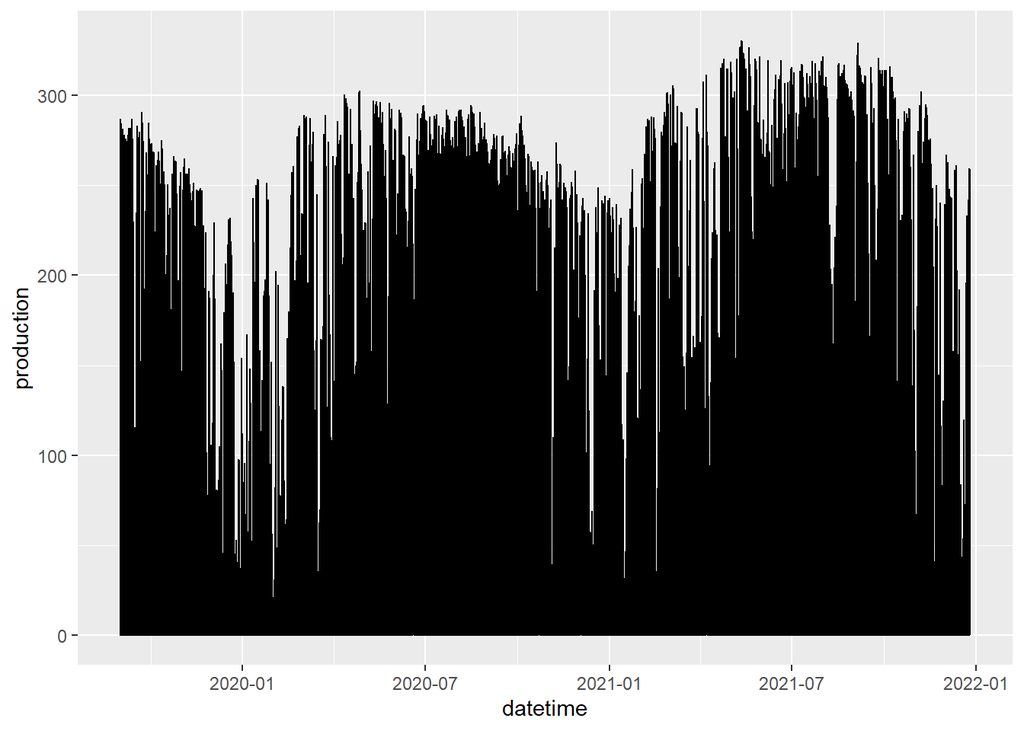

```r
train1[,datetime:=ymd(date)+dhours(hour)]
ggplot(train1 ,aes(x=datetime,y=production)) + geom_line()
```

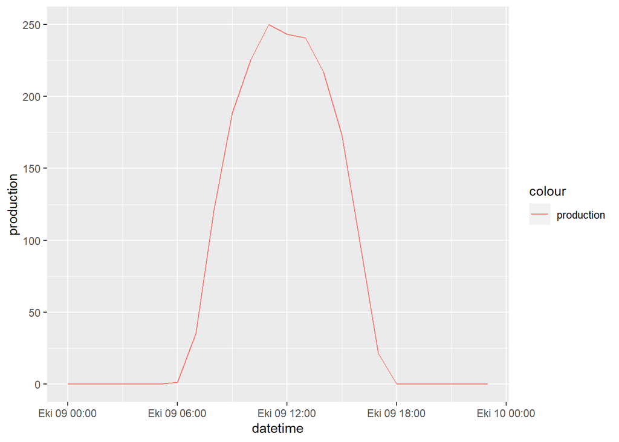

```r
ggplot(train1[date=='2020-10-09'] ,aes(x=datetime)) +
        geom_line(aes(y=production,color='production'))
```

Plotting the overall dataset and only for 1 day.

## Base Model

In the base model we only include trend, weekday, month and hour (as a factor variable instead of value) informations

```r
tmp=train1
tmp=as.data.table(tmp)
lmb=lm(production~trnd+w_day+mon+as.factor(hour),tmp)
summary(lmb)
```

```
##
## Call:
## lm(formula = production ~ trnd + w_day + mon + as.factor(hour),
##     data = tmp)
##
## Residuals:
##      Min       1Q   Median       3Q      Max
## -202.441  -20.046    1.221   28.172  108.915
##
## Coefficients:
##                     Estimate Std. Error t value Pr(>|t|)
## (Intercept)        1.641e+01  1.966e+00   8.347  < 2e-16 ***
## trnd               4.562e-04  4.995e-05   9.132  < 2e-16 ***
## w_dayCum          -7.199e-01  1.066e+00  -0.675 0.499571
## w_dayÇar          -1.981e-01  1.064e+00  -0.186 0.852354
## w_dayPaz           3.497e+00  1.064e+00   3.287 0.001015 **
## w_dayPer           5.243e-01  1.066e+00   0.492 0.623010
## w_dayPzt           5.509e-01  1.064e+00   0.518 0.604717
## w_daySal           2.032e+00  1.064e+00   1.909 0.056275 .
## monAra            -5.434e+01  1.383e+00 -39.283  < 2e-16 ***
## monEki            -1.825e+01  1.368e+00 -13.337  < 2e-16 ***
## monEyl            -8.628e+00  1.378e+00  -6.261 3.91e-10 ***
## monHaz             9.044e-01  1.501e+00   0.603 0.546687
## monKas            -3.700e+01  1.370e+00 -27.004  < 2e-16 ***
## monMar            -3.143e+01  1.498e+00 -20.990  < 2e-16 ***
## monMay            -2.616e+00  1.490e+00  -1.755 0.079255 .
## monNis            -2.001e+01  1.506e+00 -13.284  < 2e-16 ***
## monOca            -5.273e+01  1.508e+00 -34.956  < 2e-16 ***
## monŞub            -3.445e+01  1.535e+00 -22.444  < 2e-16 ***
## monTem             8.013e+00  1.487e+00   5.387 7.23e-08 ***
## as.factor(hour)1  -1.566e-03  1.972e+00  -0.001 0.999367
## as.factor(hour)2  -2.005e-03  1.972e+00  -0.001 0.999189
## as.factor(hour)3   9.242e-04  1.972e+00   0.000 0.999626
## as.factor(hour)4   1.607e-02  1.972e+00   0.008 0.993499
## as.factor(hour)5   5.895e-01  1.972e+00   0.299 0.764975
## as.factor(hour)6   7.496e+00  1.972e+00   3.801 0.000144 ***
## as.factor(hour)7   3.803e+01  1.972e+00  19.287  < 2e-16 ***
## as.factor(hour)8   9.396e+01  1.972e+00  47.646  < 2e-16 ***
## as.factor(hour)9   1.521e+02  1.972e+00  77.122  < 2e-16 ***
## as.factor(hour)10  1.954e+02  1.972e+00  99.087  < 2e-16 ***
## as.factor(hour)11  2.182e+02  1.972e+00 110.663  < 2e-16 ***
## as.factor(hour)12  2.238e+02  1.972e+00 113.469  < 2e-16 ***
## as.factor(hour)13  2.133e+02  1.972e+00 108.175  < 2e-16 ***
## as.factor(hour)14  1.885e+02  1.972e+00  95.594  < 2e-16 ***
## as.factor(hour)15  1.460e+02  1.972e+00  74.052  < 2e-16 ***
## as.factor(hour)16  9.174e+01  1.972e+00  46.521  < 2e-16 ***
## as.factor(hour)17  4.021e+01  1.972e+00  20.389  < 2e-16 ***
## as.factor(hour)18  9.942e+00  1.972e+00   5.042 4.65e-07 ***
## as.factor(hour)19  1.013e+00  1.972e+00   0.514 0.607468
## as.factor(hour)20  5.405e-03  1.972e+00   0.003 0.997813
## as.factor(hour)21 -2.839e-03  1.972e+00  -0.001 0.998851
## as.factor(hour)22 -1.442e-02  1.972e+00  -0.007 0.994166
## as.factor(hour)23 -1.412e-02  1.972e+00  -0.007 0.994287
## ---
## Signif. codes:  0 '***' 0.001 '**' 0.01 '*' 0.05 '.' 0.1 ' ' 1
##
## Residual standard error: 40.53 on 20238 degrees of freedom
## Multiple R-squared:  0.8228, Adjusted R-squared:  0.8224
## F-statistic:  2292 on 41 and 20238 DF,  p-value: < 2.2e-16
```

```r
tmp[,actual:=production]
tmp[,prediction:=predict(lmb,tmp)]
```

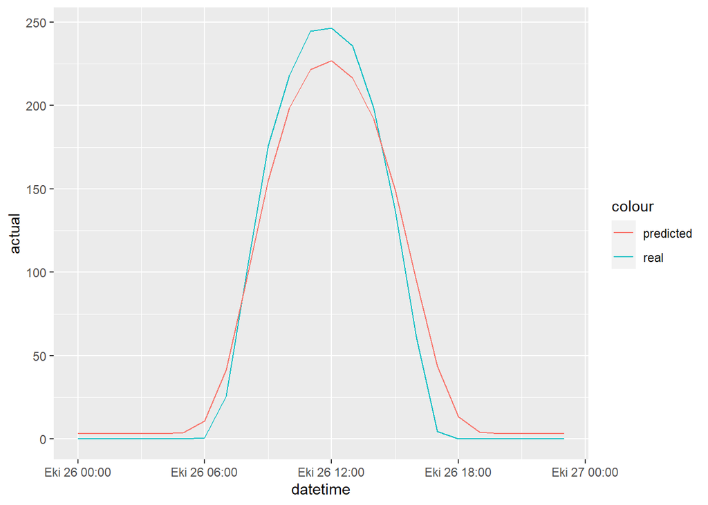

```r
ggplot(tmp[date=='2020-10-26'] ,aes(x=datetime)) +
        geom_line(aes(y=actual,color='real')) +
        geom_line(aes(y=prediction,color='predicted'))
```

In order to evaluate different models we will use mape(mean absolute percentage error values for daily basis)

```r
daily_series1=tmp[,list(avg_production=mean(production),avg_prediction=mean(prediction)),by=list(date)]
mape(daily_series1$avg_prediction,daily_series1$avg_production)
```

```
## [1] 26.08171
```

## Iteration 1

In the iterations we will create tree of residual values.

```r
tmp[,residual:=actual-prediction]

names(tmp)
```

```
##   [1] "date"
##   [2] "hour"
##   [3] "production"
##   [4] "DSWRF_surface_38_35"
##   [5] "DSWRF_surface_38_35.25"
##   [6] "DSWRF_surface_38_35.5"
##   [7] "DSWRF_surface_38_35.75"
##   [8] "DSWRF_surface_38_36"
##   [9] "DSWRF_surface_38.25_35"
##  [10] "DSWRF_surface_38.25_35.25"
##  [11] "DSWRF_surface_38.25_35.5"
##  [12] "DSWRF_surface_38.25_35.75"
##  [13] "DSWRF_surface_38.25_36"
##  [14] "DSWRF_surface_38.5_35"
##  [15] "DSWRF_surface_38.5_35.25"
```

[output cut: 170 more lines]

[figure not shown]

```r
tree1=rpart(residual~ .-date-production-trnd-actual-prediction-datetime,tmp,control=rpart.control(cp=0,maxdepth=4))
fancyRpartPlot(tree1)
```

Because of the numbers are hard to read in FancyRpartPlot we will continue with different type of plotting for trees for next iterations.

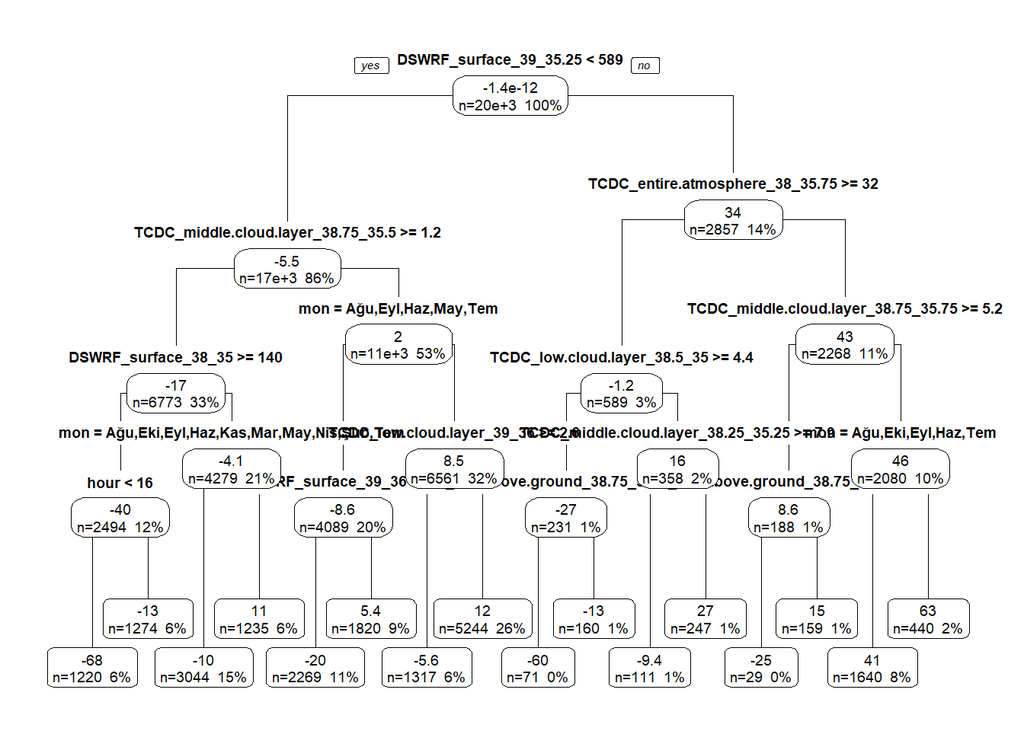

```r
prp(tree1, type = 1, extra = 101, leaf.round = 1, fallen.leaves = TRUE,
    varlen = 0, tweak = 1.5)
```

In the plot max asolute number is -68, so we should consider when we iterate our model. We will add decision variable values of the variables in the path of the maximum value of tree.

```r
tmp[,dswrf39_35.25:=as.numeric(DSWRF_surface_39_35.25<589)]
tmp[,tcdcmcl38.75_35.5:=as.numeric(TCDC_middle.cloud.layer_38.75_35.5>=1.2)]
tmp[,dswrf38_35:=as.numeric(DSWRF_surface_38_35>=140)]
tmp[,lesshour:=as.numeric(hour<16)]

lmb2=lm(production~trnd+w_day+mon+as.factor(hour)+dswrf39_35.25:tcdcmcl38.75_35.5:dswrf38_35:lesshour,tmp)

summary(lmb2)
```

```
##
## Call:
## lm(formula = production ~ trnd + w_day + mon + as.factor(hour) +
##     dswrf39_35.25:tcdcmcl38.75_35.5:dswrf38_35:lesshour, data = tmp)
##
## Residuals:
##      Min       1Q   Median       3Q      Max
## -219.330  -16.586    0.902   21.331  162.244
##
## Coefficients:
##                                                       Estimate Std. Error
## (Intercept)                                          1.141e+01  1.728e+00
## trnd                                                 5.825e-04  4.392e-05
## w_dayCum                                            -3.529e-01  9.367e-01
## w_dayÇar                                            -3.275e-01  9.350e-01
## w_dayPaz                                             3.822e+00  9.346e-01
## w_dayPer                                             1.217e+00  9.369e-01
## w_dayPzt                                             5.062e-01  9.349e-01
## w_daySal                                             2.384e+00  9.350e-01
## monAra                                              -4.513e+01  1.221e+00
## monEki                                              -1.706e+01  1.202e+00
## monEyl                                              -7.879e+00  1.211e+00
## monHaz                                               3.505e-01  1.318e+00
## monKas                                              -3.236e+01  1.205e+00
## monMar                                              -2.321e+01  1.320e+00
## monMay                                              -2.461e+00  1.309e+00
## monNis                                              -1.436e+01  1.325e+00
## monOca                                              -4.415e+01  1.329e+00
## monŞub                                              -2.859e+01  1.350e+00
## monTem                                               6.058e+00  1.307e+00
## as.factor(hour)1                                    -1.692e-03  1.732e+00
## as.factor(hour)2                                    -2.257e-03  1.732e+00
## as.factor(hour)3                                     5.452e-04  1.732e+00
## as.factor(hour)4                                     1.556e-02  1.732e+00
## as.factor(hour)5                                     5.889e-01  1.732e+00
## as.factor(hour)6                                     7.495e+00  1.732e+00
## as.factor(hour)7                                     3.803e+01  1.732e+00
## as.factor(hour)8                                     9.396e+01  1.732e+00
## as.factor(hour)9                                     1.558e+02  1.733e+00
## as.factor(hour)10                                    2.148e+02  1.750e+00
```

[output cut: 50 more lines]

```
## as.factor(hour)17                                    23.211  < 2e-16 ***
## as.factor(hour)18                                     5.729 1.03e-08 ***
## as.factor(hour)19                                     0.593   0.5535
## as.factor(hour)20                                     0.002   0.9987
## as.factor(hour)21                                    -0.003   0.9975
## as.factor(hour)22                                    -0.010   0.9921
## as.factor(hour)23                                    -0.010   0.9922
## dswrf39_35.25:tcdcmcl38.75_35.5:dswrf38_35:lesshour -77.442  < 2e-16 ***
## ---
## Signif. codes:  0 '***' 0.001 '**' 0.01 '*' 0.05 '.' 0.1 ' ' 1
##
## Residual standard error: 35.6 on 20233 degrees of freedom
##   (4 observations deleted due to missingness)
## Multiple R-squared:  0.8633, Adjusted R-squared:  0.863
## F-statistic:  3042 on 42 and 20233 DF,  p-value: < 2.2e-16
```

```r
tmp[,prediction:=predict(lmb2,tmp)]
tmp[,residual:=actual-prediction]
```

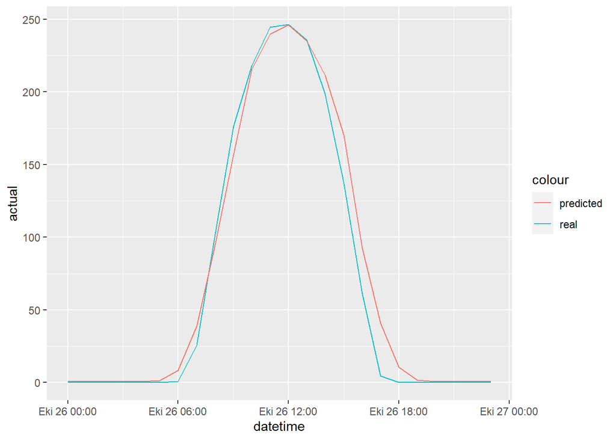

```r
ggplot(tmp[date=='2020-10-26'] ,aes(x=datetime)) +
        geom_line(aes(y=actual,color='real')) +
        geom_line(aes(y=prediction,color='predicted'))
```

```r
daily_series2=tmp[,list(avg_production=mean(production),avg_prediction=mean(prediction)),by=list(date)]
dailyseries2 = na.omit(daily_series2)

mape(dailyseries2$avg_prediction,dailyseries2$avg_production)
```

```
## [1] 21.8049
```

## Iteration2

After the new predictions and new residuals are calculated, we should repeat the previous process until we will not improve model results.

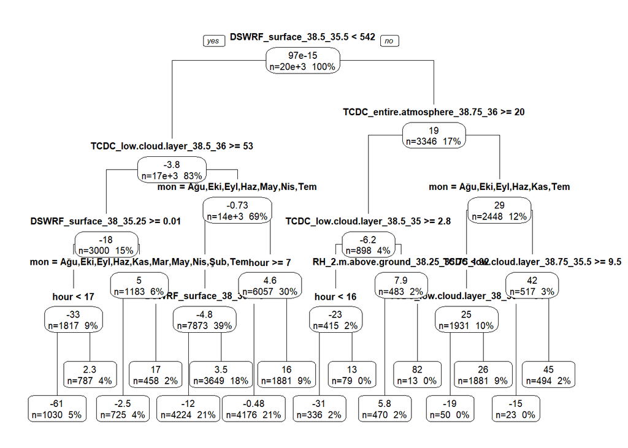

```r
tree2=rpart(residual~ .-date-production-trnd-actual-prediction-datetime,tmp,control=rpart.control(cp=0,maxdepth=4))
prp(tree2, type = 1, extra = 101, leaf.round = 1, fallen.leaves = TRUE,
    varlen = 0, tweak = 1.5)
```

Max absolute value is 82 in the tree plot, so we should take into consideration this value

```r
tmp[,dswrf38.5_35.5:=as.numeric(DSWRF_surface_38.5_35.5>=542)]
tmp[,tcdcea38.75_36:=as.numeric(TCDC_entire.atmosphere_38.75_36>=20)]
tmp[,tcdclcl38.5_35:=as.numeric(TCDC_low.cloud.layer_38.5_35<2.8)]
tmp[,rh2ag38.25_35.75:=as.numeric(RH_2.m.above.ground_38.25_35.75>=92)]

lmb3=lm(production~trnd+w_day+mon+as.factor(hour)+dswrf39_35.25:tcdcmcl38.75_35.5:dswrf38_35:lesshour
        +dswrf38.5_35.5:tcdcea38.75_36:tcdclcl38.5_35:rh2ag38.25_35.75,tmp)

summary(lmb3)
```

```
##
## Call:
## lm(formula = production ~ trnd + w_day + mon + as.factor(hour) +
##     dswrf39_35.25:tcdcmcl38.75_35.5:dswrf38_35:lesshour + dswrf38.5_35.5:tcdcea38.75_36:tcdclcl38.5_35:rh2ag38.25_35.75,
##     data = tmp)
##
## Residuals:
##      Min       1Q   Median       3Q      Max
## -219.257  -16.609    1.013   21.332  162.458
##
## Coefficients:
##                                                                 Estimate
## (Intercept)                                                    1.137e+01
## trnd                                                           5.899e-04
## w_dayCum                                                      -3.354e-01
## w_dayÇar                                                      -3.185e-01
## w_dayPaz                                                       3.713e+00
## w_dayPer                                                       1.162e+00
## w_dayPzt                                                       4.500e-01
## w_daySal                                                       2.279e+00
## monAra                                                        -4.508e+01
## monEki                                                        -1.704e+01
## monEyl                                                        -7.854e+00
## monHaz                                                         3.572e-01
## monKas                                                        -3.230e+01
## monMar                                                        -2.371e+01
## monMay                                                        -2.448e+00
## monNis                                                        -1.433e+01
## monOca                                                        -4.409e+01
## monŞub                                                        -2.867e+01
## monTem                                                         6.050e+00
## as.factor(hour)1                                               2.371e-02
## as.factor(hour)2                                               2.314e-02
## as.factor(hour)3                                               2.593e-02
## as.factor(hour)4                                               4.094e-02
## as.factor(hour)5                                               6.143e-01
## as.factor(hour)6                                               7.520e+00
## as.factor(hour)7                                               3.808e+01
## as.factor(hour)8                                               9.398e+01
## as.factor(hour)9                                               1.558e+02
```

[output cut: 143 more lines]

```
## as.factor(hour)18                                             ***
## as.factor(hour)19
## as.factor(hour)20
## as.factor(hour)21
## as.factor(hour)22
## as.factor(hour)23
## dswrf39_35.25:tcdcmcl38.75_35.5:dswrf38_35:lesshour           ***
## dswrf38.5_35.5:tcdcea38.75_36:tcdclcl38.5_35:rh2ag38.25_35.75 ***
## ---
## Signif. codes:  0 '***' 0.001 '**' 0.01 '*' 0.05 '.' 0.1 ' ' 1
##
## Residual standard error: 35.55 on 20229 degrees of freedom
##   (7 observations deleted due to missingness)
## Multiple R-squared:  0.8637, Adjusted R-squared:  0.8634
## F-statistic:  2982 on 43 and 20229 DF,  p-value: < 2.2e-16
```

```r
tmp[,prediction:=predict(lmb3,tmp)]
tmp[,residual:=actual-prediction]
```

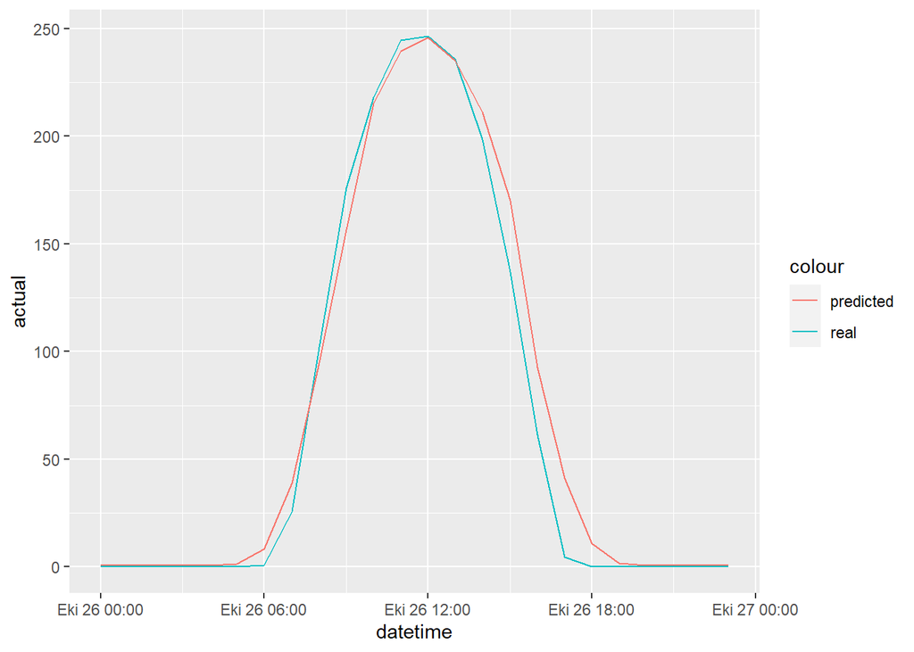

```r
ggplot(tmp[date=='2020-10-26'] ,aes(x=datetime)) +
        geom_line(aes(y=actual,color='real')) +
        geom_line(aes(y=prediction,color='predicted'))
```

```r
daily_series3=tmp[,list(avg_production=mean(production),avg_prediction=mean(prediction)),by=list(date)]
dailyseries3 = na.omit(daily_series3)
mape(dailyseries3$avg_prediction,dailyseries3$avg_production)
```

```
## [1] 21.75415
```

## Iteration 3

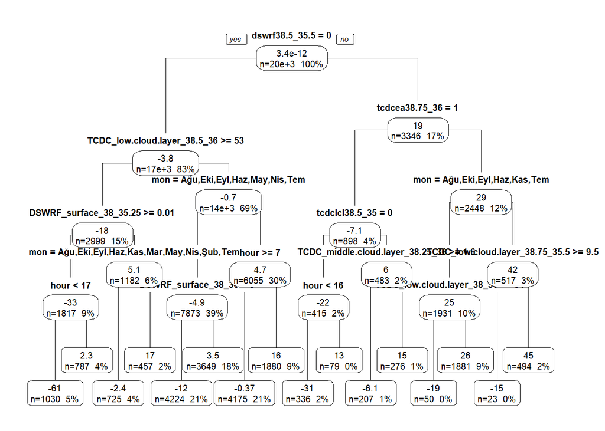

```r
tree3=rpart(residual~ .-date-production-trnd-actual-prediction-datetime,tmp,control=rpart.control(cp=0,maxdepth=4))
prp(tree3, type = 1, extra = 101, leaf.round = 1, fallen.leaves = TRUE,
    varlen = 0, tweak = 1.5)
```

Max absolute value is 61 (leftmost value) in the tree plot, so we should take into consideration this value

```r
tmp[,dswrf38.5_35.5_2:=as.numeric(dswrf38.5_35.5==0)]
tmp[,tcdclcl38.5_36:=as.numeric(TCDC_low.cloud.layer_38.5_36>=53)]
tmp[,dswrf38_35.25:=as.numeric(DSWRF_surface_38_35.25>=0.01)]
tmp[,hour2c:=as.numeric(hour<17)]

lmb4=lm(production~trnd+w_day+mon+as.factor(hour)+dswrf39_35.25:tcdcmcl38.75_35.5:dswrf38_35:lesshour
        +dswrf38.5_35.5:tcdcea38.75_36:tcdclcl38.5_35:rh2ag38.25_35.75
        +dswrf38.5_35.5_2:tcdclcl38.5_36:dswrf38_35.25:hour2c,tmp)

summary(lmb4)
```

```
##
## Call:
## lm(formula = production ~ trnd + w_day + mon + as.factor(hour) +
##     dswrf39_35.25:tcdcmcl38.75_35.5:dswrf38_35:lesshour + dswrf38.5_35.5:tcdcea38.75_36:tcdclcl38.5_35:rh2ag38.25_35.75 +
##     dswrf38.5_35.5_2:tcdclcl38.5_36:dswrf38_35.25:hour2c, data = tmp)
##
## Residuals:
##      Min       1Q   Median       3Q      Max
## -222.502  -15.821    0.894   19.375  206.222
##
## Coefficients:
##                                                                 Estimate
## (Intercept)                                                    1.153e+01
## trnd                                                           5.695e-04
## w_dayCum                                                       7.456e-01
## w_dayÇar                                                      -6.099e-01
## w_dayPaz                                                       3.512e+00
## w_dayPer                                                       1.103e+00
## w_dayPzt                                                      -3.365e-01
## w_daySal                                                       1.777e+00
## monAra                                                        -4.301e+01
## monEki                                                        -1.906e+01
## monEyl                                                        -9.608e+00
## monHaz                                                        -1.751e+00
## monKas                                                        -3.274e+01
## monMar                                                        -2.071e+01
## monMay                                                        -1.790e+00
## monNis                                                        -1.456e+01
## monOca                                                        -4.079e+01
## monŞub                                                        -2.561e+01
## monTem                                                         4.023e+00
## as.factor(hour)1                                               2.251e-02
## as.factor(hour)2                                               2.195e-02
## as.factor(hour)3                                               2.477e-02
## as.factor(hour)4                                               3.980e-02
## as.factor(hour)5                                               6.132e-01
## as.factor(hour)6                                               8.330e+00
## as.factor(hour)7                                               4.069e+01
## as.factor(hour)8                                               9.975e+01
## as.factor(hour)9                                               1.662e+02
```

[output cut: 147 more lines]

```
## as.factor(hour)19
## as.factor(hour)20
## as.factor(hour)21
## as.factor(hour)22
## as.factor(hour)23
## dswrf39_35.25:tcdcmcl38.75_35.5:dswrf38_35:lesshour           ***
## dswrf38.5_35.5:tcdcea38.75_36:tcdclcl38.5_35:rh2ag38.25_35.75 ***
## dswrf38.5_35.5_2:tcdclcl38.5_36:dswrf38_35.25:hour2c          ***
## ---
## Signif. codes:  0 '***' 0.001 '**' 0.01 '*' 0.05 '.' 0.1 ' ' 1
##
## Residual standard error: 32.08 on 20228 degrees of freedom
##   (7 observations deleted due to missingness)
## Multiple R-squared:  0.889,  Adjusted R-squared:  0.8888
## F-statistic:  3683 on 44 and 20228 DF,  p-value: < 2.2e-16
```

```r
tmp[,prediction:=predict(lmb4,tmp)]
tmp[,residual:=actual-prediction]
```

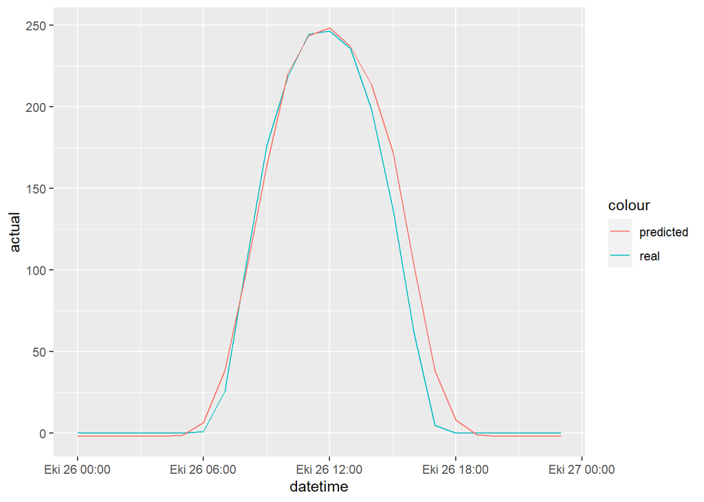

```r
ggplot(tmp[date=='2020-10-26'] ,aes(x=datetime)) +
        geom_line(aes(y=actual,color='real')) +
        geom_line(aes(y=prediction,color='predicted'))
```

```r
daily_series4=tmp[,list(avg_production=mean(production),avg_prediction=mean(prediction)),by=list(date)]
dailyseries4 = na.omit(daily_series4)
mape(dailyseries4$avg_prediction,dailyseries4$avg_production)
```

```
## [1] 19.64049
```

## Iteration4

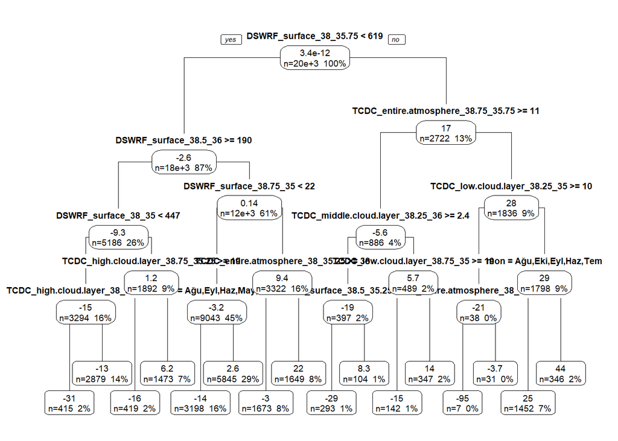

```r
tree4=rpart(residual~ .-date-production-trnd-actual-prediction-datetime,tmp,control=rpart.control(cp=0,maxdepth=4))
prp(tree4, type = 1, extra = 101, leaf.round = 1, fallen.leaves = TRUE,
    varlen = 0, tweak = 1.5)
```

Max absolute value is 95 in the tree plot, so we should take into consideration this value

```r
tmp[,dswrf38_35.75:=as.numeric(DSWRF_surface_38_35.75>=619)]
tmp[,tcdcea38.75_35.75:=as.numeric(TCDC_entire.atmosphere_38.75_35.75<11)]
tmp[,tcdclcl38.25_35:=as.numeric(TCDC_low.cloud.layer_38.25_35>=10)]
tmp[,tcdcea38_35.75:=as.numeric(TCDC_entire.atmosphere_38_35.75>=21)]

lmb5=lm(production~trnd+w_day+mon+as.factor(hour)+dswrf39_35.25:tcdcmcl38.75_35.5:dswrf38_35:lesshour
        +dswrf38.5_35.5:tcdcea38.75_36:tcdclcl38.5_35:rh2ag38.25_35.75
        +dswrf38.5_35.5_2:tcdclcl38.5_36:dswrf38_35.25:hour2c
        +dswrf38_35.75:tcdcea38.75_35.75:tcdclcl38.25_35:tcdcea38_35.75,tmp)

summary(lmb5)
```

```
##
## Call:
## lm(formula = production ~ trnd + w_day + mon + as.factor(hour) +
##     dswrf39_35.25:tcdcmcl38.75_35.5:dswrf38_35:lesshour + dswrf38.5_35.5:tcdcea38.75_36:tcdclcl38.5_35:rh2ag38.25_35.75 +
##     dswrf38.5_35.5_2:tcdclcl38.5_36:dswrf38_35.25:hour2c + dswrf38_35.75:tcdcea38.75_35.75:tcdclcl38.25_35:tcdcea38_35.75,
##     data = tmp)
##
## Residuals:
##      Min       1Q   Median       3Q      Max
## -222.863  -15.839    0.885   19.381  206.210
##
## Coefficients:
##                                                                  Estimate
## (Intercept)                                                     1.146e+01
## trnd                                                            5.691e-04
## w_dayCum                                                        7.974e-01
## w_dayÇar                                                       -5.608e-01
## w_dayPaz                                                        3.566e+00
## w_dayPer                                                        1.154e+00
## w_dayPzt                                                       -3.380e-01
## w_daySal                                                        1.801e+00
## monAra                                                         -4.300e+01
## monEki                                                         -1.906e+01
## monEyl                                                         -9.611e+00
## monHaz                                                         -1.542e+00
## monKas                                                         -3.273e+01
## monMar                                                         -2.070e+01
## monMay                                                         -1.791e+00
## monNis                                                         -1.439e+01
## monOca                                                         -4.078e+01
## monŞub                                                         -2.560e+01
## monTem                                                          4.119e+00
## as.factor(hour)1                                                2.258e-02
## as.factor(hour)2                                                2.203e-02
## as.factor(hour)3                                                2.484e-02
## as.factor(hour)4                                                3.987e-02
## as.factor(hour)5                                                6.132e-01
## as.factor(hour)6                                                8.330e+00
## as.factor(hour)7                                                4.069e+01
## as.factor(hour)8                                                9.975e+01
```

[output cut: 152 more lines]

```
## as.factor(hour)20
## as.factor(hour)21
## as.factor(hour)22
## as.factor(hour)23
## dswrf39_35.25:tcdcmcl38.75_35.5:dswrf38_35:lesshour            ***
## dswrf38.5_35.5:tcdcea38.75_36:tcdclcl38.5_35:rh2ag38.25_35.75  ***
## dswrf38.5_35.5_2:tcdclcl38.5_36:dswrf38_35.25:hour2c           ***
## dswrf38_35.75:tcdcea38.75_35.75:tcdclcl38.25_35:tcdcea38_35.75 ***
## ---
## Signif. codes:  0 '***' 0.001 '**' 0.01 '*' 0.05 '.' 0.1 ' ' 1
##
## Residual standard error: 32.04 on 20227 degrees of freedom
##   (7 observations deleted due to missingness)
## Multiple R-squared:  0.8893, Adjusted R-squared:  0.8891
## F-statistic:  3611 on 45 and 20227 DF,  p-value: < 2.2e-16
```

```r
tmp[,prediction:=predict(lmb5,tmp)]
tmp[,residual:=actual-prediction]
```

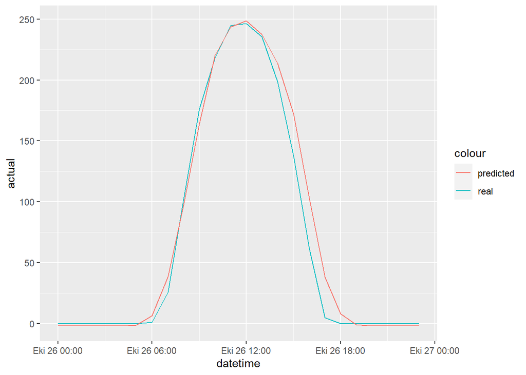

```r
ggplot(tmp[date=='2020-10-26'] ,aes(x=datetime)) +
        geom_line(aes(y=actual,color='real')) +
        geom_line(aes(y=prediction,color='predicted'))
```

```r
daily_series5=tmp[,list(avg_production=mean(production),avg_prediction=mean(prediction)),by=list(date)]
dailyseries5 = na.omit(daily_series5)
mape(dailyseries5$avg_prediction,dailyseries5$avg_production)
```

```
## [1] 19.61189
```

### Iteration 5

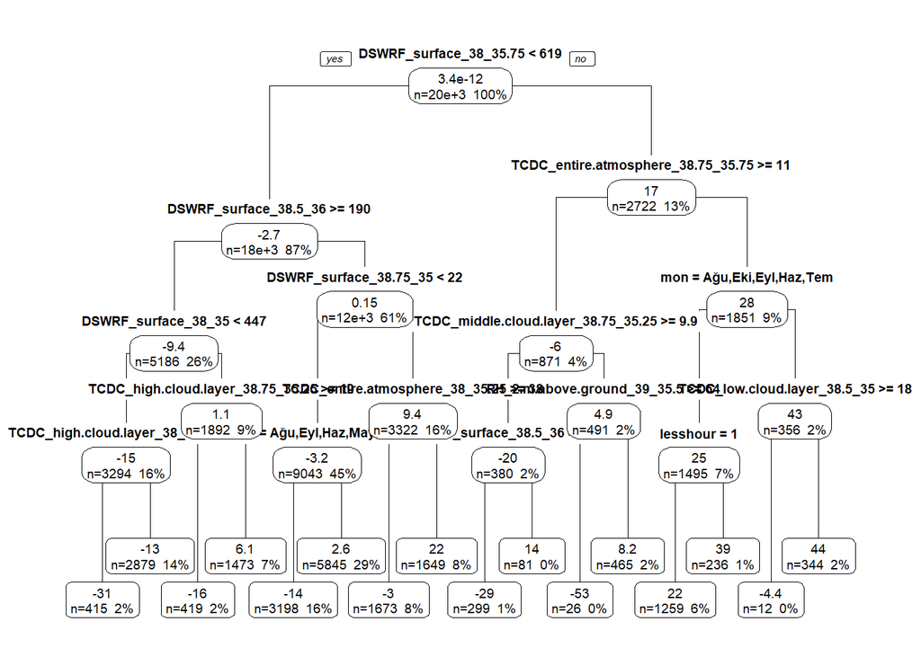

```r
tree5=rpart(residual~ .-date-production-trnd-actual-prediction-datetime,tmp,control=rpart.control(cp=0,maxdepth=4))
prp(tree5, type = 1, extra = 101, leaf.round = 1, fallen.leaves = TRUE,
    varlen = 0, tweak = 1.5)
```

```r
tmp[,dswrf38_35.75_2:=as.numeric(DSWRF_surface_38_35.75>=619)]
tmp[,tcdcea38.75_35.75_2:=as.numeric(TCDC_entire.atmosphere_38.75_35.75<11)]
tmp[,mon2:=as.numeric(!mon %in% c('Ağu','Eki','Eyl','Haz','Tem'))]
tmp[,tcdclcl38.5_35_2:=as.numeric(TCDC_low.cloud.layer_38.5_35<18)]

lmb6=lm(production~trnd+w_day+mon+as.factor(hour)+dswrf39_35.25:tcdcmcl38.75_35.5:dswrf38_35:lesshour
        +dswrf38.5_35.5:tcdcea38.75_36:tcdclcl38.5_35:rh2ag38.25_35.75
        +dswrf38.5_35.5_2:tcdclcl38.5_36:dswrf38_35.25:hour2c
        +dswrf38_35.75:tcdcea38.75_35.75:tcdclcl38.25_35:tcdcea38_35.75
        +dswrf38_35.75_2:tcdcea38.75_35.75_2:mon2:tcdclcl38.5_35_2,tmp)

summary(lmb6)
```

```
##
## Call:
## lm(formula = production ~ trnd + w_day + mon + as.factor(hour) +
##     dswrf39_35.25:tcdcmcl38.75_35.5:dswrf38_35:lesshour + dswrf38.5_35.5:tcdcea38.75_36:tcdclcl38.5_35:rh2ag38.25_35.75 +
##     dswrf38.5_35.5_2:tcdclcl38.5_36:dswrf38_35.25:hour2c + dswrf38_35.75:tcdcea38.75_35.75:tcdclcl38.25_35:tcdcea38_35.75 +
##     dswrf38_35.75_2:tcdcea38.75_35.75_2:mon2:tcdclcl38.5_35_2,
##     data = tmp)
##
## Residuals:
##      Min       1Q   Median       3Q      Max
## -220.468  -15.177    1.364   18.500  200.619
##
## Coefficients:
##                                                                  Estimate
## (Intercept)                                                     1.280e+01
## trnd                                                            5.502e-04
## w_dayCum                                                        6.136e-01
## w_dayÇar                                                       -8.868e-01
## w_dayPaz                                                        3.407e+00
## w_dayPer                                                        1.214e+00
## w_dayPzt                                                       -1.524e-01
## w_daySal                                                        1.556e+00
## monAra                                                         -4.344e+01
## monEki                                                         -1.909e+01
## monEyl                                                         -9.641e+00
## monHaz                                                         -1.472e+00
## monKas                                                         -3.293e+01
## monMar                                                         -2.280e+01
## monMay                                                         -8.215e+00
## monNis                                                         -1.784e+01
## monOca                                                         -4.127e+01
## monŞub                                                         -2.680e+01
## monTem                                                          4.242e+00
## as.factor(hour)1                                                2.177e-02
## as.factor(hour)2                                                2.123e-02
## as.factor(hour)3                                                2.407e-02
## as.factor(hour)4                                                3.912e-02
## as.factor(hour)5                                                6.125e-01
## as.factor(hour)6                                                8.309e+00
## as.factor(hour)7                                                4.063e+01
```

[output cut: 157 more lines]

```
## as.factor(hour)21
## as.factor(hour)22
## as.factor(hour)23
## dswrf39_35.25:tcdcmcl38.75_35.5:dswrf38_35:lesshour            ***
## dswrf38.5_35.5:tcdcea38.75_36:tcdclcl38.5_35:rh2ag38.25_35.75  ***
## dswrf38.5_35.5_2:tcdclcl38.5_36:dswrf38_35.25:hour2c           ***
## dswrf38_35.75:tcdcea38.75_35.75:tcdclcl38.25_35:tcdcea38_35.75 ***
## dswrf38_35.75_2:tcdcea38.75_35.75_2:mon2:tcdclcl38.5_35_2      ***
## ---
## Signif. codes:  0 '***' 0.001 '**' 0.01 '*' 0.05 '.' 0.1 ' ' 1
##
## Residual standard error: 31.42 on 20226 degrees of freedom
##   (7 observations deleted due to missingness)
## Multiple R-squared:  0.8935, Adjusted R-squared:  0.8933
## F-statistic:  3690 on 46 and 20226 DF,  p-value: < 2.2e-16
```

```r
tmp[,prediction:=predict(lmb6,tmp)]
tmp[,residual:=actual-prediction]
```

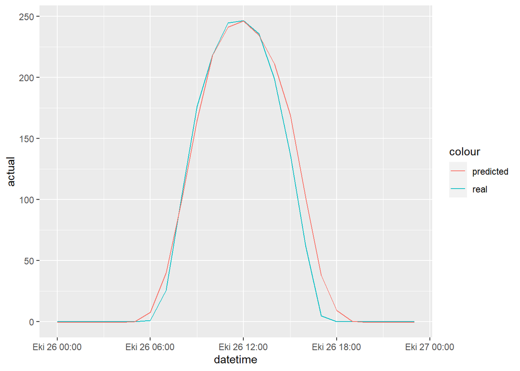

```r
ggplot(tmp[date=='2020-10-26'] ,aes(x=datetime)) +
        geom_line(aes(y=actual,color='real')) +
        geom_line(aes(y=prediction,color='predicted'))
```

```r
daily_series6=tmp[,list(avg_production=mean(production),avg_prediction=mean(prediction)),by=list(date)]
dailyseries6 = na.omit(daily_series6)
mape(dailyseries6$avg_prediction,dailyseries6$avg_production)
```

```
## [1] 18.45907
```

### Iteration6

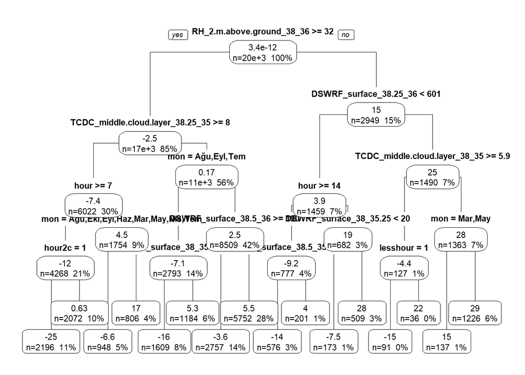

```r
tree6=rpart(residual~ .-date-production-trnd-actual-prediction-datetime,tmp,control=rpart.control(cp=0,maxdepth=4))
prp(tree6, type = 1, extra = 101, leaf.round = 1, fallen.leaves = TRUE,
    varlen = 0, tweak = 1.5)
```

Max absolute value is 29 (rightmost) in the tree plot, so we should take into consideration this value

```r
tmp[,rh2ag38_36:=as.numeric(RH_2.m.above.ground_38_36<32)]
tmp[,dswrf38.25_36:=as.numeric(DSWRF_surface_38.25_36>=601)]
tmp[,tcdcml38_35:=as.numeric(TCDC_middle.cloud.layer_38_35<5.9)]
tmp[,mon3:=as.numeric(!mon %in% c('Mar','May'))]

lmb7=lm(production~trnd+w_day+mon+as.factor(hour)+dswrf39_35.25:tcdcmcl38.75_35.5:dswrf38_35:lesshour
        +dswrf38.5_35.5:tcdcea38.75_36:tcdclcl38.5_35:rh2ag38.25_35.75
        +dswrf38.5_35.5_2:tcdclcl38.5_36:dswrf38_35.25:hour2c
        +dswrf38_35.75:tcdcea38.75_35.75:tcdclcl38.25_35:tcdcea38_35.75
        +dswrf38_35.75_2:tcdcea38.75_35.75_2:mon2:tcdclcl38.5_35_2
        +rh2ag38_36:dswrf38.25_36:tcdcml38_35:mon3,tmp)

summary(lmb7)
```

```
##
## Call:
## lm(formula = production ~ trnd + w_day + mon + as.factor(hour) +
##     dswrf39_35.25:tcdcmcl38.75_35.5:dswrf38_35:lesshour + dswrf38.5_35.5:tcdcea38.75_36:tcdclcl38.5_35:rh2ag38.25_35.75 +
##     dswrf38.5_35.5_2:tcdclcl38.5_36:dswrf38_35.25:hour2c + dswrf38_35.75:tcdcea38.75_35.75:tcdclcl38.25_35:tcdcea38_35.75 +
##     dswrf38_35.75_2:tcdcea38.75_35.75_2:mon2:tcdclcl38.5_35_2 +
##     rh2ag38_36:dswrf38.25_36:tcdcml38_35:mon3, data = tmp)
##
## Residuals:
##      Min       1Q   Median       3Q      Max
## -208.628  -14.101    0.142   16.408  188.121
##
## Coefficients:
##                                                                  Estimate
## (Intercept)                                                     5.991e+00
## trnd                                                            5.406e-04
## w_dayCum                                                        5.839e-01
## w_dayÇar                                                       -1.032e+00
## w_dayPaz                                                        3.174e+00
## w_dayPer                                                        1.154e+00
## w_dayPzt                                                       -7.427e-01
## w_daySal                                                        1.179e+00
## monAra                                                         -3.424e+01
## monEki                                                         -1.163e+01
## monEyl                                                         -5.791e+00
## monHaz                                                          6.475e+00
## monKas                                                         -2.313e+01
## monMar                                                         -1.375e+01
## monMay                                                          1.236e+00
## monNis                                                         -9.407e+00
## monOca                                                         -3.208e+01
## monŞub                                                         -1.741e+01
## monTem                                                          5.283e+00
## as.factor(hour)1                                                1.987e-02
## as.factor(hour)2                                                1.934e-02
## as.factor(hour)3                                                2.219e-02
## as.factor(hour)4                                                3.725e-02
## as.factor(hour)5                                                6.106e-01
## as.factor(hour)6                                                8.264e+00
## as.factor(hour)7                                                4.049e+01
```

[output cut: 161 more lines]

```
## as.factor(hour)22
## as.factor(hour)23
## dswrf39_35.25:tcdcmcl38.75_35.5:dswrf38_35:lesshour            ***
## dswrf38.5_35.5:tcdcea38.75_36:tcdclcl38.5_35:rh2ag38.25_35.75  ***
## dswrf38.5_35.5_2:tcdclcl38.5_36:dswrf38_35.25:hour2c           ***
## dswrf38_35.75:tcdcea38.75_35.75:tcdclcl38.25_35:tcdcea38_35.75 ***
## dswrf38_35.75_2:tcdcea38.75_35.75_2:mon2:tcdclcl38.5_35_2      ***
## rh2ag38_36:dswrf38.25_36:tcdcml38_35:mon3                      ***
## ---
## Signif. codes:  0 '***' 0.001 '**' 0.01 '*' 0.05 '.' 0.1 ' ' 1
##
## Residual standard error: 30.16 on 20225 degrees of freedom
##   (7 observations deleted due to missingness)
## Multiple R-squared:  0.9019, Adjusted R-squared:  0.9017
## F-statistic:  3957 on 47 and 20225 DF,  p-value: < 2.2e-16
```

```r
tmp[,prediction:=predict(lmb7,tmp)]
tmp[,residual:=actual-prediction]
```

```r
daily_series7=tmp[,list(avg_production=mean(production),avg_prediction=mean(prediction)),by=list(date)]
dailyseries7 = na.omit(daily_series7)
mape(dailyseries7$avg_prediction,dailyseries7$avg_production)
```

```
## [1] 17.38627
```